# Ex-4

Nurit Edri

11/18/2021

### Functional enrichment analysis

Installation of the new required packages:

```r
install.packages("gProfileR")
install.packages("knitr")
BiocManager::install("gage")
```

Loading the required packages:

```r
library(compGenomRData)
library(DESeq2)
library(gProfileR)
library(gage)
```

Loading the data:

```r
counts_file <- system.file("extdata/rna-seq/SRP029880.raw_counts.tsv",
                           package = "compGenomRData")
coldata_file <- system.file("extdata/rna-seq/SRP029880.colData.tsv",
                            package = "compGenomRData")
counts <- as.matrix(read.table(counts_file, header = T, sep = '\t'))

#remove the 'width' column
countData <- as.matrix(subset(counts, select = c(-width)))

#define the experimental setup
colData <- read.table(coldata_file, header = T, sep = '\t',
                      stringsAsFactors = TRUE)

#define the design formula
designFormula <- "~ group"

#create a DESeq dataset object from the count matrix and the colData
dds <- DESeqDataSetFromMatrix(countData = countData,
                              colData = colData,
                              design = as.formula(designFormula))
dds <- DESeq(dds)

DEresults = results(dds, contrast = c("group", 'CASE', 'CTRL'))
```

Let’s select the genes that are significantly differentially expressed between the case and control samples. Let’s extract genes that have an adjusted p-value below 0.1 and that show a 2-fold change (either negative or positive) in the case compared to control. We will then feed this gene set into the gProfileR function.

```r
#remove genes with NA values
DE <- DEresults[!is.na(DEresults$padj),]

#select genes with adjusted p-values below 0.1
DE <- DE[DE$padj < 0.1,]

#select genes with absolute log2 fold change above 1 (two-fold change)
DE <- DE[abs(DE$log2FoldChange) > 1,]

#get the list of genes of interest
genesOfInterest <- rownames(DE)

#calculate enriched GO terms
goResults <- gprofiler(query = genesOfInterest,
                       organism = 'hsapiens',
                       src_filter = 'GO',
                       hier_filtering = 'moderate')
```

1. Re-run gProfileR, this time using pathway annotations such as KEGG, REACTOME, and protein complex databases such as CORUM, in addition to the GO terms. Sort the resulting tables by columns `precision` and/or `recall`. How do the top GO terms change when sorted for `precision`, `recall`, or `p.value`? hint: use `order()` for sorting. [Difficulty: **Beginner**]

```r
goResults1 <- gprofiler(query = genesOfInterest,
                       organism = 'hsapiens',
                       src_filter = 'KEGG',
                       hier_filtering = 'moderate')
goResults2 <- gprofiler(query = genesOfInterest,
                       organism = 'hsapiens',
                       src_filter = 'REAC',
                       hier_filtering = 'moderate')
goResults3 <- gprofiler(query = genesOfInterest,
                       organism = 'hsapiens',
                       src_filter = 'CORUM',
                       hier_filtering = 'moderate')
goResultspvalue <- goResults[order(goResults$p.value),]
goResultsprecision <- goResults[order(goResults$precision),]
goResultsrecall <- goResults[order(goResults$recall),]
```

#### Gene set enrichment analysis

We use the bioconductor package gage to demonstrate how to do GSEA using normalized expression data of the samples as input.

```r
#Let's define the first gene set as the list of genes from one of the
#significant GO terms found in the GO analysis. order go results by pvalue
goResults <- goResults[order(goResults$p.value),]

#restrict the terms that have at most 100 genes overlapping with the query
go <- goResults[goResults$overlap.size < 100,]

# use the top term from this table to create a gene set
geneSet1 <- unlist(strsplit(go[1,]$intersection, ','))

#Define another gene set by just randomly selecting 25 genes from the counts
#table get normalized counts from DESeq2 results
normalizedCounts <- DESeq2::counts(dds, normalized = TRUE)

geneSet2 <- sample(rownames(normalizedCounts), 25)

geneSets <- list('top_GO_term' = geneSet1,
                 'random_set' = geneSet2)

# Using the defined gene sets, we’d like to do a group comparison between the case
# samples with respect to the control samples.

#Use the normalized counts to carry out a GSEA.
gseaResults <- gage(exprs = log2(normalizedCounts+1),
                    ref = match(rownames(colData[colData$group =='CTRL',]),
                                colnames(normalizedCounts)),
                    samp = match(rownames(colData[colData$group == 'CASE',]),
                                 colnames(normalizedCounts)),
                    gsets = geneSets, compare = 'as.group')
```

2. Repeat the gene set enrichment analysis by trying different options for the `compare` argument of the `GAGE:gage` function. How do the results differ? [Difficulty: **Beginner**]

```r
gseaResults1 <- gage(exprs = log2(normalizedCounts+1),
                    ref = match(rownames(colData[colData$group =='CTRL',]),
                                colnames(normalizedCounts)),
                    samp = match(rownames(colData[colData$group == 'CASE',]),
                                 colnames(normalizedCounts)),
                    gsets = geneSets, compare = 'paired')
print(gseaResults1)
```

```
## $greater
##                p.geomean stat.mean        p.val        q.val set.size
## top_GO_term 9.613676e-09 6.6491250 2.034802e-36 4.069605e-36       32
## random_set  3.744876e-01 0.1775541 3.453206e-01 3.453206e-01       25
##                   CASE_1       CASE_2       CASE_3       CASE_4       CASE_5
## top_GO_term 3.537417e-08 1.591399e-09 3.172477e-08 4.891313e-08 9.400654e-10
## random_set  2.778146e-01 8.770027e-01 3.473968e-01 3.401217e-01 2.558414e-01
##
## $less
##             p.geomean stat.mean     p.val q.val set.size    CASE_1    CASE_2
## random_set  0.4907548 0.1775541 0.6546794     1       25 0.7221854 0.1229973
## top_GO_term 1.0000000 6.6491250 1.0000000     1       32 1.0000000 1.0000000
##                CASE_3    CASE_4    CASE_5
## random_set  0.6526032 0.6598783 0.7441586
## top_GO_term 1.0000000 1.0000000 1.0000000
##
## $stats
##             stat.mean    CASE_1    CASE_2    CASE_3    CASE_4    CASE_5
## top_GO_term 6.6491250 6.3445922  7.138365 6.3130458 6.1748746 7.2747473
## random_set  0.1775541 0.5935606 -1.176495 0.3947853 0.4147164 0.6612027
```

```r
gseaResults2 <- gage(exprs = log2(normalizedCounts+1),
                    ref = match(rownames(colData[colData$group =='CTRL',]),
                                colnames(normalizedCounts)),
                    samp = match(rownames(colData[colData$group == 'CASE',]),
                                 colnames(normalizedCounts)),
                    gsets = geneSets, compare = 'unpaired')
print(gseaResults2)
```

```
## $greater
##                p.geomean stat.mean        p.val        q.val set.size
## top_GO_term 1.148544e-08 6.6083638 4.515501e-36 9.031003e-36       32
## random_set  3.894086e-01 0.1581673 3.620530e-01 3.620530e-01       25
##                   CASE_1       CASE_2       CASE_3       CASE_4       CASE_5
## top_GO_term 2.514557e-08 6.294789e-09 2.157509e-08 2.383455e-08 2.642881e-09
## random_set  3.452210e-01 8.133048e-01 2.380375e-01 4.331151e-01 3.445466e-01
##
## $less
##             p.geomean stat.mean    p.val q.val set.size   CASE_1    CASE_2
## random_set  0.5001347 0.1581673 0.637947     1       25 0.654779 0.1866952
## top_GO_term 1.0000000 6.6083638 1.000000     1       32 1.000000 1.0000000
##                CASE_3    CASE_4    CASE_5
## random_set  0.7619625 0.5668849 0.6554534
## top_GO_term 1.0000000 1.0000000 1.0000000
##
## $stats
##             stat.mean    CASE_1     CASE_2    CASE_3   CASE_4    CASE_5
## top_GO_term 6.6083638 6.4006248  6.7491251 6.4433925 6.429462 7.0192142
## random_set  0.1581673 0.4010812 -0.9015741 0.7188918 0.169416 0.4030215
```

3. Make a scatter plot of GO term sizes and obtained p-values by setting the `gProfiler::gprofiler` argument `significant = FALSE`. Is there a correlation of term sizes and p-values? (Hint: Take -log10 of p-values). If so, how can this bias be mitigated? [Difficulty: **Intermediate**]

```r
goResults <- gprofiler(query = genesOfInterest,
                       organism = 'hsapiens',
                       significant = FALSE ,
                       src_filter = 'GO',
                       hier_filtering = 'moderate')
```

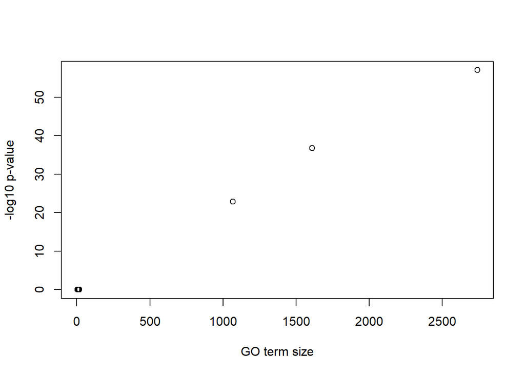

```r
x1 = goResults$term.size
y1 = -log10(goResults$p.value)
plot(x1,y1, xlab = "GO term size", ylab = "-log10 p-value")
```

4. Do a gene-set enrichment analysis using gene sets from top 10 GO terms. [Difficulty: **Intermediate**]

```r
geneSet3 <- unlist(strsplit(go[1:10,]$intersection, ','))

geneSet3 <- list(geneSet3)

gseaResults3 <- gage(exprs = log2(normalizedCounts+1),
                    ref = match(rownames(colData[colData$group =='CTRL',]),
                                colnames(normalizedCounts)),
                    samp = match(rownames(colData[colData$group == 'CASE',]),
                                 colnames(normalizedCounts)),
                    gsets = geneSet3, compare = 'as.group')
print(gseaResults3)
```

```
## $greater
##      p.geomean stat.mean p.val q.val set.size exp1
## [1,]        NA       NaN    NA    NA      628   NA
##
## $less
##      p.geomean stat.mean p.val q.val set.size exp1
## [1,]        NA       NaN    NA    NA      628   NA
##
## $stats
##      stat.mean exp1
## [1,]       NaN   NA
```

5. What are the other available R packages that can carry out gene set enrichment analysis for RNA-seq datasets? [Difficulty: **Intermediate**] GOStat, clusterProfiler, topGO
6. Use the topGO package (https://bioconductor.org/packages/release/bioc/html/topGO.html) to re-do the GO term analysis. Compare and contrast the results with what has been obtained using the `gProfileR` package. Which tool is faster, `gProfileR` or topGO? Why? [Difficulty: **Advanced**]

```r
library(topGO)
# I don't understand how to use this package.
```

7. Given a gene set annotated for human, how can it be utilized to work on *C. elegans* data? (Hint: See `biomaRt::getLDS`). [Difficulty: **Advanced**]

```r
library(biomaRt)


human <- useEnsembl("ensembl", dataset = "hsapiens_gene_ensembl")
celegans <- useEnsembl("ensembl", dataset = "celegans_gene_ensembl")


getLDS(attributes = c("hgnc_symbol", "start_position"),
       filters = "hgnc_symbol", values = "TP53",
       mart = human,
       attributesL = c("ensembl_gene_id","start_position"),
       martL = celegans)
```

```
## [1] HGNC.symbol       Gene.start..bp.   Gene.stable.ID    Gene.start..bp..1
## <0 rows> (or 0-length row.names)
```

8. Import curated pathway gene sets with Entrez identifiers from the [MSIGDB database](http://software.broadinstitute.org/gsea/msigdb/collections.jsp) and re-do the GSEA for all curated gene sets. [Difficulty: **Advanced**]

```r
curatedpathway_genesets <- read.delim("C:/Users/nurit/Downloads/c2.cp.v7.4.entrez.gmt", header=FALSE)
   View(curatedpathway_genesets)

   # I don't understand how to use this table for GSEA
```